# rsmFlow: Optimization, Optimum Uncertainty, and Economics

# Optimization, optimum uncertainty, and economics

**Role in the vignette curriculum.** This deep dive owns constrained optimization, target search, optimizer comparison, uncertainty in optimum coordinates, joint regions, near-optimal operating zones, uncertainty-aware optimization, optimum stability, and biological-versus-economic decisions. Multiresponse trade-offs are developed in the next vignette.

## 1. An optimum is an estimated decision, not a fact

A response-surface optimum depends on:

- model specification;
- estimated parameters;
- factor bounds;
- optimization objective;
- optimizer behavior;
- uncertainty in the fitted surface.

Therefore, a defensible analysis reports more than one coordinate vector.

For optimum inference, uncertainty in the factor settings themselves is central (Wan et al. 2016).

## 2. Load and fit the agronomic example

```r
library(rsmFlow)
p <- system.file("extdata","agronomy_rsm_nonorthogonal.csv",package="rsmFlow")
dat <- read.csv(p)
fit <- rsm_fit(dat,"Yield",c("N","K","Irrigation"),order=2)
rsm_diagnostics(fit)
```

```
#> $n
#> [1] 25
#>
#> $p
#> [1] 10
#>
#> $rank
#> [1] 10
#>
#> $condition_number_raw
#> [1] 1824762
#>
#> $condition_number_scaled
#> [1] 28.28437
#>
#> $vif
#>               N               K      Irrigation          I(N^2)          I(K^2)
#>       136.61940       133.20810       142.65060        71.16864        63.76819
#> I(Irrigation^2)             N:K    N:Irrigation    K:Irrigation
#>        83.29273        60.20522        70.56865        66.46196
#>
#> $residuals
#>           1           2           3           4           5           6
#>  0.05398739 -0.11380464 -0.09437074  0.01933640  0.03877029  0.13028311
#>           7           8           9          10          11          12
#> -0.01142372  0.05870271 -0.08300412  0.09265534 -0.05997973  0.07559473
#>          13          14          15          16          17          18
#> -0.07704034 -0.07267736  0.13972652  0.02666161  0.05804077 -0.10210610
#>          19          20          21          22          23          24
#>  0.04242296  0.03265806 -0.05260165  0.19137103 -0.26599180 -0.12189940
#>          25
#>  0.09468867
#>
#> $fitted
#>        1        2        3        4        5        6        7        8
#> 8.750642 5.834430 7.442983 6.938544 8.940605 5.905499 8.052339 7.042678
#>        9       10       11       12       13       14       15       16
#> 8.506452 6.672848 8.066397 7.561176 8.769362 6.175290 8.622977 7.294578
#>       17       18       19       20       21       22       23       24
#> 8.760188 7.476694 8.674659 8.750642 8.750642 8.750642 8.750642 8.750642
```

[output cut: 50 more lines]

```
#>
#> $lack_of_fit$pure_error
#>         SS         df         MS
#> 0.13729158 6.00000000 0.02288193
#>
#> $lack_of_fit$lack_of_fit
#>         SS         df         MS          F    p.value
#> 0.11677349 9.00000000 0.01297483 0.56703399 0.78684360
#>
#> $lack_of_fit$residual
#>         SS         df
#>  0.2540651 15.0000000
#>
#> $lack_of_fit$reference
#> [1] "cell-means"
```

Only continue if model adequacy is scientifically acceptable.

## 3. Stationary geometry versus bounded decision

```r
can <- rsm_canonical(fit)
can
```

```
#> Canonical analysis
#> Nature: maximum
#> Stationary point:
#>           N           K  Irrigation
#> 137.2206244  95.9724829   0.8134653
#> Predicted response: 9.243603
#> Inside region: TRUE
```

The stationary point solves the unconstrained quadratic geometry. The operational decision is restricted to feasible bounds.

```r
opt <- rsm_optimize(
  fit,
  goal="max",
  method="hybrid",
  seed=601
)
opt
```

```
#> rsmFlow optimum
#> Goal: max  | method: L-BFGS-B
#>           N           K  Irrigation
#> 137.2206244  95.9724828   0.8134653
#> Predicted response: 9.243603
```

### Interpretation

If the bounded optimum lies on a factor limit, report that explicitly. A boundary optimum means the experiment supports a best point **within the tested region**, not necessarily a global biological maximum.

## 4. Explicit bounds

```r
b <- list(
  lower = c(N = min(dat$N), K = min(dat$K), Irrigation = min(dat$Irrigation)),
  upper = c(N = max(dat$N), K = max(dat$K), Irrigation = max(dat$Irrigation))
)

opt_b <- rsm_optimize(
  fit,
  goal="max",
  method="L-BFGS-B",
  bounds=b
)
```

Use tighter bounds when engineering, agronomic, regulatory, or safety constraints restrict the feasible operating region.

## 5. Grid search

```r
opt_grid <- rsm_optimize(
  fit,
  goal="max",
  method="grid",
  grid_n=41
)
```

Grid search is transparent and useful for teaching and verification, but resolution grows rapidly with dimensionality.

## 6. L-BFGS-B

```r
opt_lbfgs <- rsm_optimize(
  fit,
  goal="max",
  method="L-BFGS-B"
)
```

Efficient for smooth bounded surfaces.

## 7. Genetic algorithm

```r
opt_ga <- rsm_optimize(
  fit,
  goal="max",
  method="GA",
  seed=602,
  ga_control=list(popSize=100,maxiter=400,run=80)
)
```

Use a stochastic global search when multimodality or difficult constraints make local search less reliable. Freeze the seed for reproducibility.

## 8. Hybrid optimization

```r
opt_hybrid <- rsm_optimize(
  fit,
  goal="max",
  method="hybrid",
  seed=602
)
```

Hybrid optimization combines global exploration with local refinement.

## 9. Compare all methods

```r
all_opt <- rsm_optimize(
  fit,
  goal="max",
  method="all",
  seed=602
)
all_opt
```

```
#> rsmFlow optimum
#> Goal: max  | method: L-BFGS-B
#>           N           K  Irrigation
#> 137.2206244  95.9724828   0.8134653
#> Predicted response: 9.243603
```

### Interpretation

Agreement among methods on a smooth surface increases confidence in numerical optimization. Disagreement should trigger inspection of flat ridges, multiple local extrema, scaling, and bounds.

## 10. Minimize a response

```r
# Example for disease or contaminant concentration:
# rsm_optimize(disease_fit, goal="min", method="hybrid", seed=603)
```

The same framework applies to maximization and minimization.

## 11. Hit a target instead of max/min

Suppose a response should be near a quality target rather than as large as possible.

```r
opt_target <- rsm_optimize(
  fit,
  goal="target",
  target=85,
  method="hybrid",
  seed=604
)
```

Target optimization is useful for pH, firmness, concentration, moisture, and quality specifications.

## 12. Why optimum coordinates are uncertain

If fitted coefficients are random, the optimum is a derived random quantity:

$$\hat{\mathbf{x}}_{opt}=h(\hat{\boldsymbol\beta}).$$

A coefficient table does not directly quantify uncertainty in $h(\cdot)$.

## 13. Bootstrap / coefficient-simulation optimum uncertainty

```r
unc <- rsm_optimum_ci(
  fit,
  optimum=opt_hybrid,
  B=999,
  conf=.95,
  optimizer="L-BFGS-B",
  seed=605
)
unc
```

```
#> $estimate
#>           N           K  Irrigation   predicted
#> 137.2206244  95.9724828   0.8134653   9.2436034
#>
#> $intervals
#>                  lower       upper
#> N          135.0104316 139.7435920
#> K           93.4737092  99.1153411
#> Irrigation   0.7876625   0.8406279
#> predicted    9.1654273   9.3286165
#>
#> $bootstrap
#>            N         K Irrigation predicted
#> 1   137.8289  96.05985  0.8263358  9.260135
#> 2   136.7204  96.00084  0.8158511  9.250538
```

[output cut: 1018 more lines]

Inspect successful and failed re-optimizations. Failed replicates are information about numerical or model instability and should not be silently discarded.

## 14. Plot the optimum cloud

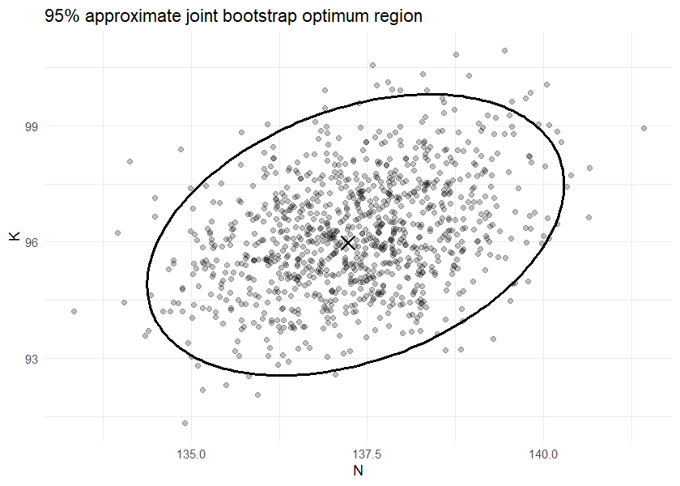

```r
rsm_plot_optimum_uncertainty(
  unc,
  x="N",
  y="K",
  conf=.95
)
```

For three-factor models, plot multiple 2D projections or conditional summaries.

### Interpretation

An elongated cloud indicates correlated uncertainty in factor settings. A cloud concentrated on a boundary can indicate truncation by the feasible region rather than precise knowledge of an unconstrained biological optimum.

## 15. Joint optimum region

```r
reg <- rsm_optimum_region(
  unc,
  factors=c("N","K"),
  conf=.95,
  n=300
)
head(reg)
```

```
#> $center
#>        N        K
#> 137.3321  96.1866
#>
#> $covariance
#>           N         K
#> N 1.4613949 0.6399143
#> K 0.6399143 2.1989014
#>
#> $conf
#> [1] 0.95
#>
#> $factors
#> [1] "N" "K"
#>
#> $cutoff
#> [1] 5.991465
#>
#> $method
#> [1] "bootstrap covariance ellipsoid"
```

The current implementation is an approximate region based on the bootstrap/simulation distribution; it should not be described as an exact Fieller-type confidence set.

## 16. Near-optimal region

A practical operating zone can be more useful than a single point.

```r
near <- rsm_near_optimal(
  fit,
  optimum=opt_hybrid,
  tolerance=.05,
  goal="max",
  n=41,
  max_points=150000,
  seed=606
)
head(near)
```

```
#>              N        K Irrigation predicted
#> 19628 135.8812 90.90625    0.61925  8.783290
#> 19629 137.9375 90.90625    0.61925  8.792829
#> 19630 139.9938 90.90625    0.61925  8.795974
#> 19631 142.0500 90.90625    0.61925  8.792727
#> 19632 144.1062 90.90625    0.61925  8.783087
#> 19669 135.8812 92.37500    0.61925  8.796613
```

For maximization, a 5% tolerance represents points with fitted response close to the best fitted response under the function’s definition.

### Interpretation

Near-optimal regions can reveal opportunities to:

- reduce input without substantial yield loss;
- choose settings less sensitive to operational error;
- avoid poorly predicted boundaries;
- trade small response losses for economic or environmental benefits.

## 17. Optimum stability

```r
stab <- rsm_optimum_stability(
  unc,
  fit,
  tolerance=.10
)
stab
```

```
#> $tolerance
#> [1] 0.1
#>
#> $probability_within_standardized_radius
#> [1] 0.998999
#>
#> $standardized_distance_quantiles
#>        50%        80%        90%        95%
#> 0.03486189 0.05134089 0.05981144 0.06832985
#>
#> $response_loss_quantiles
#>          50%          80%          90%          95%
#> 0.0004028046 0.0008150425 0.0011007262 0.0014162962
#>
#> $model_kind
#> [1] "gaussian_rsm"
#>
#> $interpretation
#> [1] "Stability uses factor-range standardized distance and relative fitted-response loss."
```

This asks whether uncertainty replicates stay within a practically acceptable neighborhood of the reference decision.

## 18. Uncertainty-aware optimization

```r
rob <- rsm_robust_optimize(
  fit,
  goal="max",
  lambda=1.96,
  method="L-BFGS-B",
  seed=607
)
rob
```

```
#> $solution
#>           N           K  Irrigation
#> 136.4200320  94.7962020   0.8092862
#>
#> $predicted
#> [1] 9.241717
#>
#> $se
#> [1] 0.05158978
#>
#> $confidence_bound
#> [1] 9.140601
#>
#> $goal
#> [1] "max"
#>
#> $lambda
#> [1] 1.96
#>
#> $method
#> [1] "L-BFGS-B"
```

This penalizes poorly supported high predictions according to the package’s uncertainty criterion.

### Interpretation

A conservative optimum can be preferable when the apparent peak is located in a region of high prediction uncertainty.

## 19. Visual comparison of fitted and conservative decisions

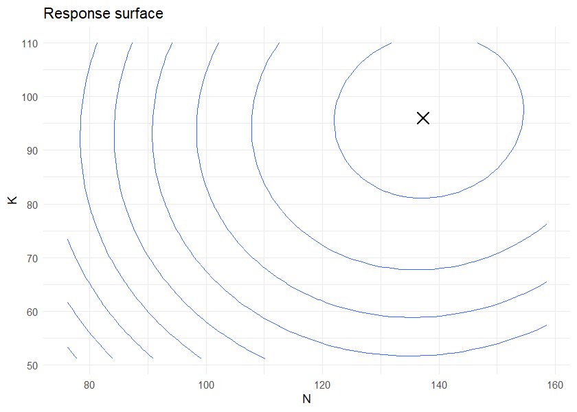

```r
rsm_plot(
  fit,
  type="contour",
  x="N",
  y="K",
  at=list(Irrigation=median(dat$Irrigation)),
  optimum=opt_hybrid
)
```

Add the uncertainty-aware point in a custom `ggplot2` layer when preparing publication figures.

## 20. Economic optimization

Biological maximum:

$$\max_{\mathbf x}\hat y(\mathbf x).$$

Economic objective:

$$\max_{\mathbf x}\left[
P_y\hat y(\mathbf x)
-\sum_i c_i(x_i-x_{i,0})
-C_0
\right].$$

Here $x_{i,0}$ is a baseline at which incremental factor cost begins.

```r
eco <- rsm_economic_optimum(
  fit,
  response_price=12,
  factor_cost=c(
    N=0.80,
    K=0.55,
    Irrigation=35
  ),
  fixed_cost=120,
  baseline=c(
    N=min(dat$N),
    K=min(dat$K),
    Irrigation=min(dat$Irrigation)
  ),
  method="L-BFGS-B",
  seed=608
)
eco
```

```
#> $solution
#>          N          K Irrigation
#> 92.0576104 66.6298812  0.7445486
#>
#> $predicted_response
#> [1] 6.965184
#>
#> $revenue
#> [1] 83.58221
#>
#> $variable_plus_fixed_cost
#> [1] 150.0142
#>
#> $profit
#> [1] -66.43202
#>
#> $method
#> [1] "L-BFGS-B"
#>
#> $biological_optimum
#>           N           K  Irrigation
#> 137.2206258  95.9724803   0.8134653
#>
#> $biological_predicted
#> [1] 9.243603
#>
#> $model_kind
#> [1] "gaussian_rsm"
#>
#> $interpretation
#> [1] "Economic optimum maximizes fitted revenue minus declared costs inside the experimental region."
```

## 21. Why baseline matters

Using incremental input above a baseline prevents nonsensical negative costs when factors are coded around zero. Economic assumptions should be stated in natural units.

## 22. Biological versus economic optimum

Report both:

```r
eco$biological_optimum
```

```
#>           N           K  Irrigation
#> 137.2206258  95.9724803   0.8134653
```

```r
eco$solution
```

```
#>          N          K Irrigation
#> 92.0576104 66.6298812  0.7445486
```

### Interpretation

The economic optimum can use less input than the biological maximum because the marginal response no longer pays for the marginal input.

This is a decision consequence, not evidence that the biological model was wrong.

## 23. Sensitivity to price assumptions

```r
prices <- c(8,10,12,15,20)

sens <- lapply(prices, function(py) {
  ans <- rsm_economic_optimum(
    fit,
    response_price=py,
    factor_cost=c(N=.80,K=.55,Irrigation=35),
    fixed_cost=120,
    baseline=c(N=min(dat$N),K=min(dat$K),Irrigation=min(dat$Irrigation)),
    method="L-BFGS-B"
  )
  cbind(data.frame(price=py), as.data.frame(as.list(ans$solution)), data.frame(profit=ans$profit))
})
do.call(rbind,sens)
```

```
#>   price         N        K Irrigation     profit
#> 1     8  76.25000 52.44379  0.7025143 -90.007344
#> 2    10  83.15527 60.71619  0.7306455 -79.451395
#> 3    12  92.05761 66.62988  0.7445486 -66.432019
#> 4    15 101.09135 72.49831  0.7583337 -44.169187
#> 5    20 110.12353 78.36657  0.7721178  -3.419148
```

### Interpretation

An economic optimum without sensitivity to uncertain prices can be less informative than a near-optimal economic region across plausible prices.

## 24. Boundary optima need explicit language

If any optimal coordinate equals its lower or upper bound, write:

> “The best fitted setting within the experimental region occurred on the upper N boundary.”

Do not write:

> “The true optimum N rate is the upper tested dose.”

The first is supported by the experiment. The second extrapolates beyond the evidence.

## 25. Uncertainty method depends on model family

For Gaussian polynomial models, coefficient simulation and bootstrap-style workflows are natural.

For likelihood GLMs, parametric simulate/refit/re-optimize is preferred where implemented.

For quasi families, asymptotic coefficient simulation is more appropriate than pretending a full likelihood exists.

For nonlinear models, refit bootstrap is preferable when the error model supports it; generalized nonlinear variance/correlation structures need additional care.

Always inspect the `method` stored in the uncertainty object.

## 26. Three decision scenarios

### Scenario A: sharp interior maximum

Expect a compact optimum cloud and relatively small near-optimal zone.

### Scenario B: broad plateau

Expect large coordinate uncertainty but potentially stable predicted response. Report an operating zone rather than one coordinate.

### Scenario C: boundary optimum

Expect truncation. Consider a new experiment beyond the current boundary only if scientifically feasible and safe.

## 27. Three complete code recipes

### Classical yield maximum

```r
fit <- rsm_fit(dat,"Yield",c("N","K","Irrigation"),order=2)
opt <- rsm_optimize(fit,goal="max",method="hybrid",seed=700)
unc <- rsm_optimum_ci(fit,optimum=opt,B=999,seed=700)
near <- rsm_near_optimal(fit,optimum=opt,tolerance=.05,seed=700)
```

### GLM pest minimum

```r
# pest_fit <- rsm_glm_fit(pest,"Count",c("Dose","Time"),family=poisson())
# pest_opt <- rsm_optimize(pest_fit,goal="min",scale="response")
# pest_unc <- rsm_optimum_ci(pest_fit,pest_opt,B=999,seed=701)
```

### Nonlinear fertilizer maximum

```r
# nl_fit <- rsm_nonlinear_fit(nd,"Yield",c("N","P"),
#   model="mitscherlich2_product",start="ga",seed=702)
# nl_opt <- rsm_optimize(nl_fit,goal="max",method="hybrid",seed=702)
# nl_unc <- rsm_optimum_ci(nl_fit,nl_opt,B=999,seed=702)
```

## 28. Common mistakes

1. Reporting the unconstrained stationary point as a feasible recommendation.
2. Ignoring boundary status.
3. Giving optimum coordinates without uncertainty.
4. Hiding failed bootstrap/refit replicates.
5. Treating a covariance ellipse approximation as an exact confidence region.
6. Reporting a single point when a broad near-optimal zone exists.
7. Optimizing a model that failed diagnostics.
8. Using economic costs on coded units without defining a natural-unit baseline.
9. Treating one price scenario as permanent truth.

## 29. Minimum reporting checklist

- Objective (`max`, `min`, `target`) stated.
- Factor bounds stated in natural units.
- Optimization method reported.
- Random seed reported for stochastic optimization.
- Boundary coordinates identified.
- Uncertainty method, B, and confidence level reported.
- Failed uncertainty replicates reported.
- Joint region described as approximate when appropriate.
- Near-optimal tolerance defined.
- Stability criterion defined.
- Economic price/cost units stated.
- Cost baseline stated.
- Biological and economic optima distinguished.
- Price/cost sensitivity considered when decisions depend strongly on them.

## 30. Where to go next

Continue to **Multiresponse Optimization and Tier 3** when several responses conflict or when simple response-surface engines do not adequately represent the predictive structure.

Wan, Fang, Wei Liu, Frank Bretz, and Yang Han. 2016. “Confidence Sets for Optimal Factor Levels of a Response Surface.” *Biometrics* 72 (4): 1285–93. https://doi.org/10.1111/biom.12500.